# Reproducable research peer assignment 1

This is the report for the peer assignment for reproducable research.

Loading and preprocessing the data show any code that is needed to load the data (i.e. read.csv()) Process/transform the data (if necessary) into a format suitable for your analysis

```r
library(ggplot2)
data <- read.table('./activity.csv', sep = ",", na.strings = "NA", header=TRUE)
data$date <- as.Date(data$date)
```

## What is mean total number of steps taken per day?

For this part of the assignment, you can ignore the missing values in the dataset. - Make a histogram of the total number of steps taken each day - Calculate and report the mean and median total number of steps taken per day

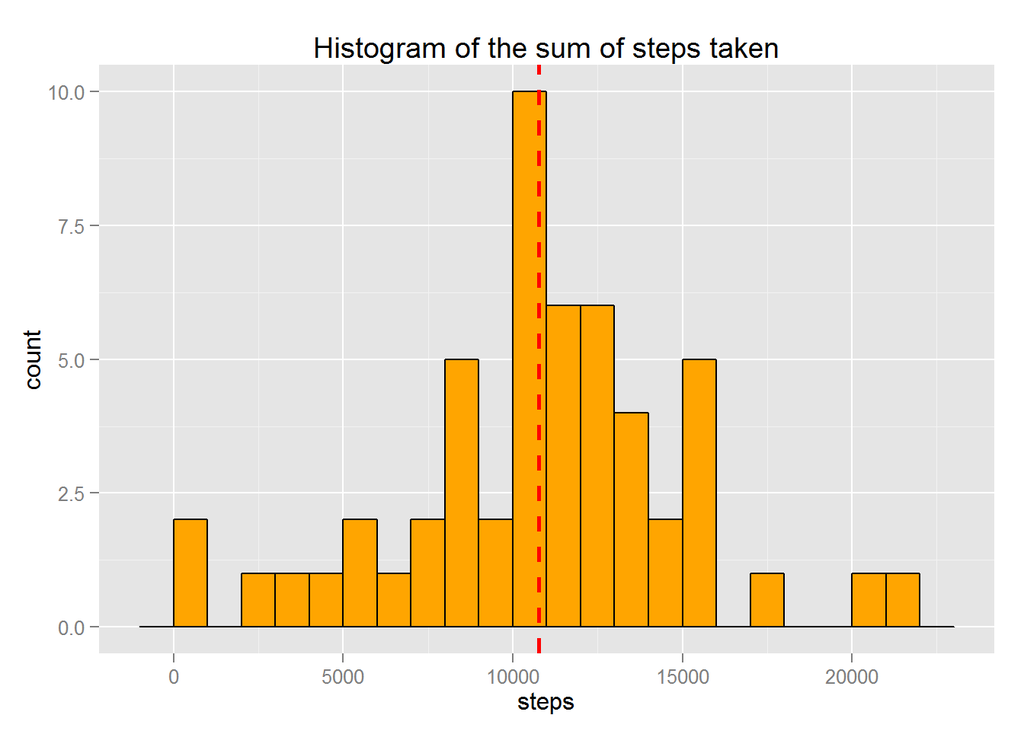

```r
step_per_day <- aggregate(steps ~ date, data=data, FUN=sum)
ggplot(step_per_day, aes(steps)) +
    geom_histogram(binwidth=1000, colour = "black", fill="orange") +
    geom_vline(aes(xintercept=mean(steps)),
               color="red", linetype="dashed", size=1) +
    ggtitle("Histogram of the sum of steps taken")
```

calculate the mean and median

```r
mean(step_per_day$steps)
```

```
## [1] 10766.19
```

```r
median(step_per_day$steps)
```

```
## [1] 10765
```

## What is the average daily activity pattern?

The following part is looking at the average steps per interval (5 minutes) accross all days

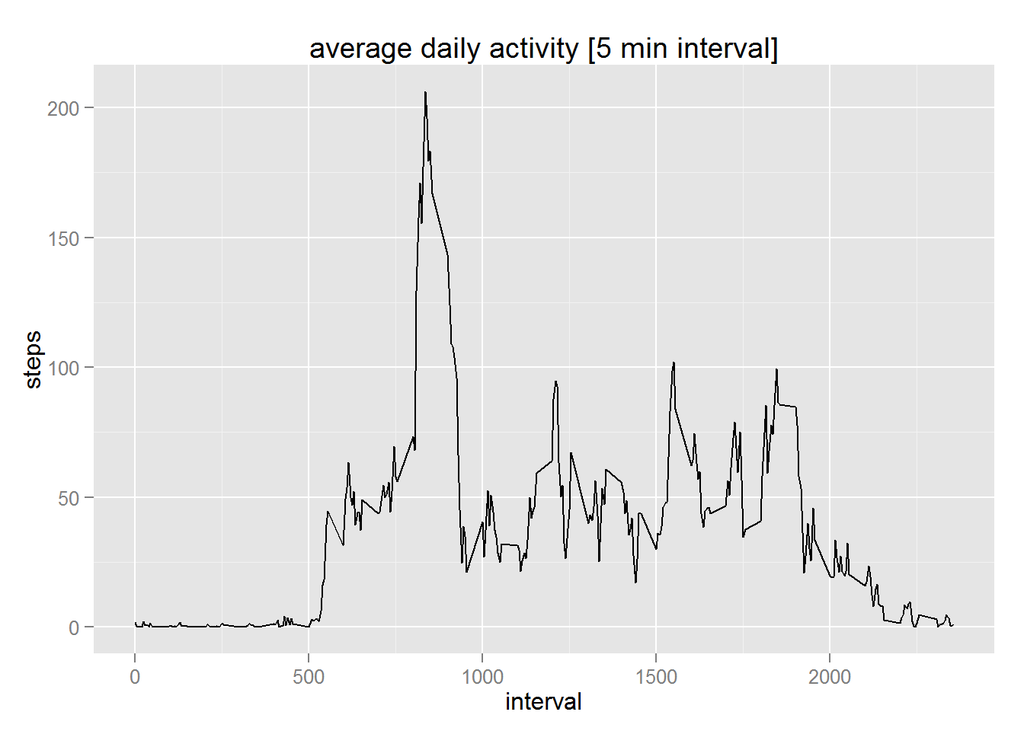

```r
intervals <- aggregate(steps ~ interval, data, mean)
ggplot(intervals, aes(interval, steps)) +
    geom_line() +
    ggtitle("average daily activity [5 min interval]")
```

```r
intervals$interval[which.max(intervals$steps)]
```

```
## [1] 835
```

## Imputing missing values

- Calculate and report the total number of missing values in the dataset (i.e. the total number of rows with NAs)

```r
sum(is.na(data))
```

```
## [1] 2304
```

- Devise a strategy for filling in all of the missing values in the dataset. The strategy does not need to be sophisticated. For example, you could use the mean/median for that day, or the mean for that 5 minute interval, etc.

replacing NA with mean

```r
activities <- data
activities$steps[is.na(data$steps)] <- tapply(data$steps, data$interval, mean, na.rm = TRUE)
total_step_na_replacement <- tapply(activities$steps, activities$date, sum)
total_step_original <- tapply(data$steps, data$date, sum)
```

comparing via summary

```r
summary(total_step_na_replacement)
```

```
##    Min. 1st Qu.  Median    Mean 3rd Qu.    Max.
##      41    9819   10770   10770   12810   21190
```

```r
summary(total_step_original)
```

```
##    Min. 1st Qu.  Median    Mean 3rd Qu.    Max.    NA's
##      41    8841   10760   10770   13290   21190       8
```

From the summary we can see that the result are close to eachother. The differences are not that big

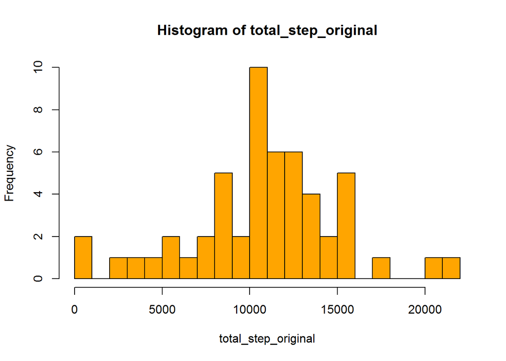

```r
hist(total_step_original, col = "orange", breaks=20)
```

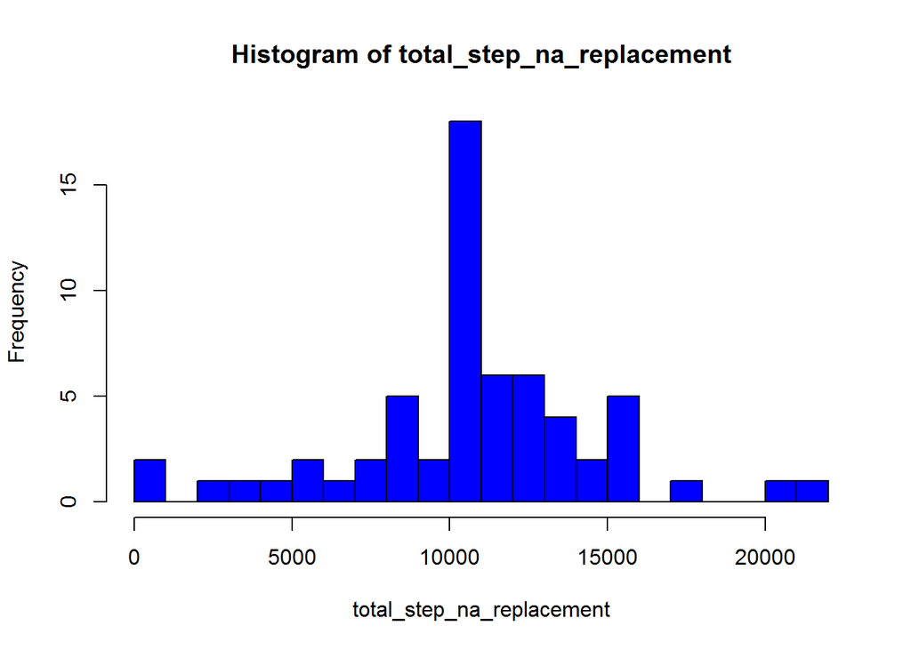

```r
hist(total_step_na_replacement, col = "blue", breaks = 20)
```

## Are there differences in activity patterns between weekdays and weekends?

Create a new factor variable in the dataset with two levels - “weekday” and “weekend” indicating whether a given date is a weekday or weekend day.

```r
weekday <- function(date) {
    if (weekdays(as.Date(date)) %in% c("Saturday", "Sunday")) {
        "weekend"
    } else {
        "weekday"
    }
}
activities$daytype <- as.factor(sapply(activities$date, weekday))
activities_aggregated <- aggregate(steps ~ interval + daytype, activities, mean)
```

creating the plots per day type

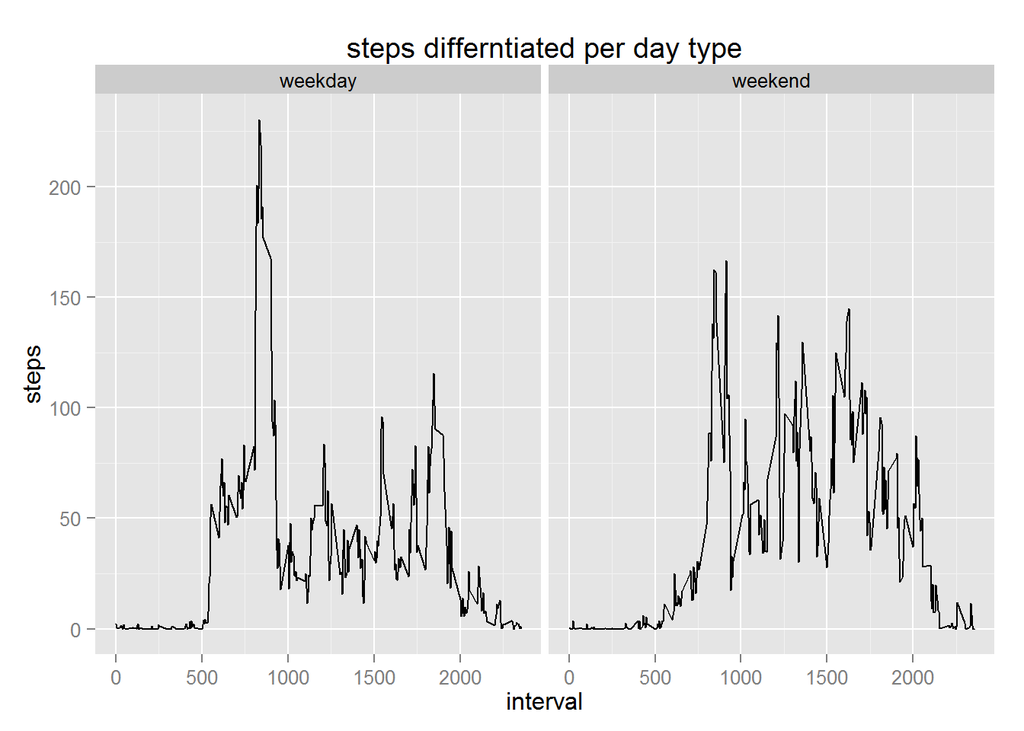

```r
ggplot(activities_aggregated, aes(interval, steps)) +
    geom_line() +
    facet_grid(. ~daytype, scales="free") +
    ggtitle("steps differntiated per day type")
```